# OTX2 loxP7 architectures

Pierre Murat

02 January, 2025

This notebook report the analysis of the architectures identified from the scrambling of the loxP7 heterogeneous cell populations

```r
setwd("/lustre/scratch126/gengen/projects/escramble")
```

# 1 Basecalling

Basecalling is performed with dorado for each run idependently and resulting fastq files are combined

```bash
# FARM

# Load modules
module load HGI/softpack/groups/escramble/eSCRAMBLE/7

################################################
# 15/07/24 run

# Replicate 1
bsub -q "gpu-basement" -gpu - -R'select[mem>32000] rusage[mem=32000]' -M 32000 \
-o /lustre/scratch126/gengen/projects/escramble/Data/ONT/240715/FASTQ/dorado_OTX2_14_1_scramble_rep_1.log -J dorado_OTX2_14_1_scramble_rep_1 \
'dorado basecaller hac --no-trim --emit-fastq \
/lustre/scratch126/gengen/projects/escramble/Data/ONT/240715/240715_PM_OTX2_14_1/20240715_1352_MN40897_FAX17531_3c89a6d0/pod5/ \
> /lustre/scratch126/gengen/projects/escramble/Data/ONT/240715/FASTQ/OTX2_14_1_scramble_rep_1.fastq'

# Replicate 2
bsub -q "gpu-basement" -gpu - -R'select[mem>32000] rusage[mem=32000]' -M 32000 \
-o /lustre/scratch126/gengen/projects/escramble/Data/ONT/240715/FASTQ/dorado_OTX2_14_1_scramble_rep_2.log -J dorado_OTX2_14_1_scramble_rep_2 \
'dorado basecaller hac --no-trim --emit-fastq \
/lustre/scratch126/gengen/projects/escramble/Data/ONT/240715/240715_PM_OTX2_14_2/20240715_1401_MN44968_FAX27331_ad69607c/pod5/ \
> /lustre/scratch126/gengen/projects/escramble/Data/ONT/240715/FASTQ/OTX2_14_1_scramble_rep_2.fastq'

# Read statistics
bsub -q normal -n 16 -R'select[mem>32000] rusage[mem=32000]' -M 32000 \
-o /lustre/scratch126/gengen/projects/escramble/Data/ONT/240715/FASTQ/seqkit.stats.log \
'seqkit stats /lustre/scratch126/gengen/projects/escramble/Data/ONT/240715/FASTQ/OTX2_14_1_scramble_rep_1.fastq > /lustre/scratch126/gengen/projects/escramble/Data/ONT/240715/FASTQ/OTX2_14_1_scramble_rep_1_stats.txt
seqkit stats /lustre/scratch126/gengen/projects/escramble/Data/ONT/240715/FASTQ/OTX2_14_1_scramble_rep_2.fastq > /lustre/scratch126/gengen/projects/escramble/Data/ONT/240715/FASTQ/OTX2_14_1_scramble_rep_2_stats.txt'

# Rep 1: 4,112,864 reads
# Rep 2: 3,605,987 reads

################################################
# 30/07/24 run

# Replicate 1
bsub -q "gpu-basement" -gpu - -R'select[mem>32000] rusage[mem=32000]' -M 32000 \
-o /lustre/scratch126/gengen/projects/escramble/Data/ONT/240730/FASTQ/dorado_OTX2_14_1_scramble_rep_1.log -J dorado_OTX2_14_1_scramble_rep_1 \
'dorado basecaller hac --no-trim --emit-fastq \
/lustre/scratch126/gengen/projects/escramble/Data/ONT/240730/240730_PM_OTX2_14_1/20240730_1247_MN44968_FAZ53299_5809b5cd/pod5/ \
> /lustre/scratch126/gengen/projects/escramble/Data/ONT/240730/FASTQ/OTX2_14_1_scramble_rep_1.fastq'

# Replicate 2
bsub -q "gpu-basement" -gpu - -R'select[mem>32000] rusage[mem=32000]' -M 32000 \
-o /lustre/scratch126/gengen/projects/escramble/Data/ONT/240730/FASTQ/dorado_OTX2_14_1_scramble_rep_2.log -J dorado_OTX2_14_1_scramble_rep_2 \
'dorado basecaller hac --no-trim --emit-fastq \
/lustre/scratch126/gengen/projects/escramble/Data/ONT/240730/240730_PM_OTX2_14_2/20240730_1247_MN40897_FAZ58256_50638a1e/pod5/ \
> /lustre/scratch126/gengen/projects/escramble/Data/ONT/240730/FASTQ/OTX2_14_1_scramble_rep_2.fastq'

# Read statistics
bsub -q normal -n 16 -R'select[mem>32000] rusage[mem=32000]' -M 32000 \
-o /lustre/scratch126/gengen/projects/escramble/Data/ONT/240730/FASTQ/seqkit.stats.log \
'seqkit stats /lustre/scratch126/gengen/projects/escramble/Data/ONT/240730/FASTQ/OTX2_14_1_scramble_rep_1.fastq > /lustre/scratch126/gengen/projects/escramble/Data/ONT/240730/FASTQ/OTX2_14_1_scramble_rep_1_stats.txt
seqkit stats /lustre/scratch126/gengen/projects/escramble/Data/ONT/240730/FASTQ/OTX2_14_1_scramble_rep_2.fastq > /lustre/scratch126/gengen/projects/escramble/Data/ONT/240730/FASTQ/OTX2_14_1_scramble_rep_2_stats.txt'

# Rep 1: 4,809,861 reads
# Rep 2: 4,132,531 reads

################################################
# 31/07/24 run

# Replicate 1
bsub -q "gpu-basement" -gpu - -R'select[mem>32000] rusage[mem=32000]' -M 32000 \
-o /lustre/scratch126/gengen/projects/escramble/Data/ONT/240731/FASTQ/dorado_OTX2_14_1_scramble_rep_1.log -J dorado_OTX2_14_1_scramble_rep_1 \
'dorado basecaller hac --no-trim --emit-fastq \
/lustre/scratch126/gengen/projects/escramble/Data/ONT/240731/240730_PM_OTX2_14_1/20240731_1022_MN44968_FAZ53299_431d21e1/pod5/ \
> /lustre/scratch126/gengen/projects/escramble/Data/ONT/240731/FASTQ/OTX2_14_1_scramble_rep_1.fastq'

# Replicate 2
bsub -q "gpu-basement" -gpu - -R'select[mem>32000] rusage[mem=32000]' -M 32000 \
-o /lustre/scratch126/gengen/projects/escramble/Data/ONT/240731/FASTQ/dorado_OTX2_14_1_scramble_rep_2.log -J dorado_OTX2_14_1_scramble_rep_2 \
'dorado basecaller hac --no-trim --emit-fastq \
/lustre/scratch126/gengen/projects/escramble/Data/ONT/240731/240730_PM_OTX2_14_2/20240731_1022_MN40897_FAZ58256_75821d5e/pod5/ \
> /lustre/scratch126/gengen/projects/escramble/Data/ONT/240731/FASTQ/OTX2_14_1_scramble_rep_2.fastq'

# Read statistics
bsub -q normal -n 16 -R'select[mem>32000] rusage[mem=32000]' -M 32000 \
-o /lustre/scratch126/gengen/projects/escramble/Data/ONT/240731/FASTQ/seqkit.stats.log \
'seqkit stats /lustre/scratch126/gengen/projects/escramble/Data/ONT/240731/FASTQ/OTX2_14_1_scramble_rep_1.fastq > /lustre/scratch126/gengen/projects/escramble/Data/ONT/240731/FASTQ/OTX2_14_1_scramble_rep_1_stats.txt
seqkit stats /lustre/scratch126/gengen/projects/escramble/Data/ONT/240731/FASTQ/OTX2_14_1_scramble_rep_2.fastq > /lustre/scratch126/gengen/projects/escramble/Data/ONT/240731/FASTQ/OTX2_14_1_scramble_rep_2_stats.txt'

# Rep 1: 2,020,384 reads
# Rep 2: 2,442,818 reads

# Total number of reads

# Rep 1: 10,943,109 reads
# Rep 2: 10,181,336 reads
```

Combine sequencing runs

```bash
# FARM

# Replicate 1

cat \
/lustre/scratch126/gengen/projects/escramble/Data/ONT/240715/FASTQ/OTX2_14_1_scramble_rep_1.fastq \
/lustre/scratch126/gengen/projects/escramble/Data/ONT/240730/FASTQ/OTX2_14_1_scramble_rep_1.fastq \
/lustre/scratch126/gengen/projects/escramble/Data/ONT/240731/FASTQ/OTX2_14_1_scramble_rep_1.fastq \
> /lustre/scratch126/gengen/projects/escramble/Data/ONT/240731/FASTQ/OTX2_14_1_scramble_rep_1_combined.fastq

# Replicate 2

cat \
/lustre/scratch126/gengen/projects/escramble/Data/ONT/240715/FASTQ/OTX2_14_1_scramble_rep_2.fastq \
/lustre/scratch126/gengen/projects/escramble/Data/ONT/240730/FASTQ/OTX2_14_1_scramble_rep_2.fastq \
/lustre/scratch126/gengen/projects/escramble/Data/ONT/240731/FASTQ/OTX2_14_1_scramble_rep_2.fastq \
> /lustre/scratch126/gengen/projects/escramble/Data/ONT/240731/FASTQ/OTX2_14_1_scramble_rep_2_combined.fastq
```

# 2 Demultiplexing

Sample are then demultiplexed with seqkit. WARNING: we use seqkit grep and seqkit amplicon. seqkit amplicon is only available in seqkit v2 and above (not available in Softpack for now). We need to call for a custom installation.

Primers used for PCR amplification: - all #1257: TCTCAACATCAAAGAGCACCCCT / AGGGGTGCTCTTTGATGTTGAGA - very dim #1697: GGTGCTG-AAGAAAGTTGTCGGTGTCTTTGTG-ACCAGCATTGCTTGGAAGTGTT / AACACTTCCAAGCAATGCTGGT-CACAAAGACACCGACAACTTTCTT-CAGCACC - dim #1698: GGTGCTG-TCGATTCCGTTTGTAGTCGTCTGT-ACCAGCATTGCTTGGAAGTGTT / AACACTTCCAAGCAATGCTGGT-ACAGACGACTACAAACGGAATCGA-CAGCACC - bright #1700: GTGCTG-TTCGGATTCTATCGTGTTTCCCTA-ACCAGCATTGCTTGGAAGTGTT / AACACTTCCAAGCAATGCTGGT-TAGGGAAACACGATAGAATCCGAA-CAGCAC - very bright #1721 GGTGCTG-CTTGTCCAGGGTTTGTGTAACCTT-ACCAGCATTGCTTGGAAGTGTT / AACACTTCCAAGCAATGCTGGT-AAGGTTACACAAACCCTGGACAAG-CAGCACC

```bash
# FARM

# Load modules
module load HGI/softpack/groups/escramble/eSCRAMBLE/7

# Replicate 1

# Rep 1 - very dim
bsub -q normal -n 16 -R'select[mem>32000] rusage[mem=32000]' -M 32000 \
-o /lustre/scratch126/gengen/projects/escramble/Data/ONT/240731/FASTQ/seqkit.demux.log \
'/nfs/users/nfs_j/jk24/000_Software/miniconda3/bin/seqkit grep --by-seq --max-mismatch 2 -j 16 --pattern "GGTGCTGAAGAAAGTTGTCGGTGTCTTTGTG" /lustre/scratch126/gengen/projects/escramble/Data/ONT/240731/FASTQ/OTX2_14_1_scramble_rep_1_combined.fastq \
> /lustre/scratch126/gengen/projects/escramble/Data/ONT/240731/FASTQ/OTX2_14_1_scramble_very_dim_rep_1_temp.fastq
/nfs/users/nfs_j/jk24/000_Software/miniconda3/bin/seqkit amplicon -I --max-mismatch 4 -j 8 -F "TCTCAACATCAAAGAGCACCCCT" -R "ACCAGCATTGCTTGGAAGTGTT" /lustre/scratch126/gengen/projects/escramble/Data/ONT/240731/FASTQ/OTX2_14_1_scramble_very_dim_rep_1_temp.fastq \
> /lustre/scratch126/gengen/projects/escramble/Data/ONT/240731/FASTQ/OTX2_14_1_scramble_very_dim_rep_1.fastq'

# Rep 1 - dim
bsub -q normal -n 16 -R'select[mem>32000] rusage[mem=32000]' -M 32000 \
-o /lustre/scratch126/gengen/projects/escramble/Data/ONT/240731/FASTQ/seqkit.demux.log \
'/nfs/users/nfs_j/jk24/000_Software/miniconda3/bin/seqkit grep --by-seq --max-mismatch 2 -j 16 --pattern "GGTGCTGTCGATTCCGTTTGTAGTCGTCTGT" /lustre/scratch126/gengen/projects/escramble/Data/ONT/240731/FASTQ/OTX2_14_1_scramble_rep_1_combined.fastq \
> /lustre/scratch126/gengen/projects/escramble/Data/ONT/240731/FASTQ/OTX2_14_1_scramble_dim_rep_1_temp.fastq
/nfs/users/nfs_j/jk24/000_Software/miniconda3/bin/seqkit amplicon -I --max-mismatch 4 -j 8 -F "TCTCAACATCAAAGAGCACCCCT" -R "ACCAGCATTGCTTGGAAGTGTT" /lustre/scratch126/gengen/projects/escramble/Data/ONT/240731/FASTQ/OTX2_14_1_scramble_dim_rep_1_temp.fastq \
> /lustre/scratch126/gengen/projects/escramble/Data/ONT/240731/FASTQ/OTX2_14_1_scramble_dim_rep_1.fastq'

# Rep 1 - bright
bsub -q normal -n 16 -R'select[mem>32000] rusage[mem=32000]' -M 32000 \
-o /lustre/scratch126/gengen/projects/escramble/Data/ONT/240731/FASTQ/seqkit.demux.log \
'/nfs/users/nfs_j/jk24/000_Software/miniconda3/bin/seqkit grep --by-seq --max-mismatch 2 -j 16 --pattern "GTGCTGTTCGGATTCTATCGTGTTTCCCTA" /lustre/scratch126/gengen/projects/escramble/Data/ONT/240731/FASTQ/OTX2_14_1_scramble_rep_1_combined.fastq \
> /lustre/scratch126/gengen/projects/escramble/Data/ONT/240731/FASTQ/OTX2_14_1_scramble_bright_rep_1_temp.fastq
/nfs/users/nfs_j/jk24/000_Software/miniconda3/bin/seqkit amplicon -I --max-mismatch 4 -j 8 -F "TCTCAACATCAAAGAGCACCCCT" -R "ACCAGCATTGCTTGGAAGTGTT" /lustre/scratch126/gengen/projects/escramble/Data/ONT/240731/FASTQ/OTX2_14_1_scramble_bright_rep_1_temp.fastq \
> /lustre/scratch126/gengen/projects/escramble/Data/ONT/240731/FASTQ/OTX2_14_1_scramble_bright_rep_1.fastq'

# Rep 1 - very bright
bsub -q normal -n 16 -R'select[mem>32000] rusage[mem=32000]' -M 32000 \
-o /lustre/scratch126/gengen/projects/escramble/Data/ONT/240731/FASTQ/seqkit.demux.log \
'/nfs/users/nfs_j/jk24/000_Software/miniconda3/bin/seqkit grep --by-seq --max-mismatch 2 -j 16 --pattern "GGTGCTGCTTGTCCAGGGTTTGTGTAACCTT" /lustre/scratch126/gengen/projects/escramble/Data/ONT/240731/FASTQ/OTX2_14_1_scramble_rep_1_combined.fastq \
> /lustre/scratch126/gengen/projects/escramble/Data/ONT/240731/FASTQ/OTX2_14_1_scramble_very_bright_rep_1_temp.fastq
/nfs/users/nfs_j/jk24/000_Software/miniconda3/bin/seqkit amplicon -I --max-mismatch 4 -j 8 -F "TCTCAACATCAAAGAGCACCCCT" -R "ACCAGCATTGCTTGGAAGTGTT" /lustre/scratch126/gengen/projects/escramble/Data/ONT/240731/FASTQ/OTX2_14_1_scramble_very_bright_rep_1_temp.fastq \
> /lustre/scratch126/gengen/projects/escramble/Data/ONT/240731/FASTQ/OTX2_14_1_scramble_very_bright_rep_1.fastq'

# Replicate 2

# Rep 2 - very dim
bsub -q normal -n 16 -R'select[mem>32000] rusage[mem=32000]' -M 32000 \
-o /lustre/scratch126/gengen/projects/escramble/Data/ONT/240731/FASTQ/seqkit.demux.log \
'/nfs/users/nfs_j/jk24/000_Software/miniconda3/bin/seqkit grep --by-seq --max-mismatch 2 -j 16 --pattern "GGTGCTGAAGAAAGTTGTCGGTGTCTTTGTG" /lustre/scratch126/gengen/projects/escramble/Data/ONT/240731/FASTQ/OTX2_14_1_scramble_rep_2_combined.fastq \
> /lustre/scratch126/gengen/projects/escramble/Data/ONT/240731/FASTQ/OTX2_14_1_scramble_very_dim_rep_2_temp.fastq
/nfs/users/nfs_j/jk24/000_Software/miniconda3/bin/seqkit amplicon -I --max-mismatch 4 -j 8 -F "TCTCAACATCAAAGAGCACCCCT" -R "ACCAGCATTGCTTGGAAGTGTT" /lustre/scratch126/gengen/projects/escramble/Data/ONT/240731/FASTQ/OTX2_14_1_scramble_very_dim_rep_2_temp.fastq \
> /lustre/scratch126/gengen/projects/escramble/Data/ONT/240731/FASTQ/OTX2_14_1_scramble_very_dim_rep_2.fastq'

# Rep 2 - dim
bsub -q normal -n 16 -R'select[mem>32000] rusage[mem=32000]' -M 32000 \
-o /lustre/scratch126/gengen/projects/escramble/Data/ONT/240731/FASTQ/seqkit.demux.log \
'/nfs/users/nfs_j/jk24/000_Software/miniconda3/bin/seqkit grep --by-seq --max-mismatch 2 -j 16 --pattern "GGTGCTGTCGATTCCGTTTGTAGTCGTCTGT" /lustre/scratch126/gengen/projects/escramble/Data/ONT/240731/FASTQ/OTX2_14_1_scramble_rep_2_combined.fastq \
> /lustre/scratch126/gengen/projects/escramble/Data/ONT/240731/FASTQ/OTX2_14_1_scramble_dim_rep_2_temp.fastq
/nfs/users/nfs_j/jk24/000_Software/miniconda3/bin/seqkit amplicon -I --max-mismatch 4 -j 8 -F "TCTCAACATCAAAGAGCACCCCT" -R "ACCAGCATTGCTTGGAAGTGTT" /lustre/scratch126/gengen/projects/escramble/Data/ONT/240731/FASTQ/OTX2_14_1_scramble_dim_rep_2_temp.fastq \
> /lustre/scratch126/gengen/projects/escramble/Data/ONT/240731/FASTQ/OTX2_14_1_scramble_dim_rep_2.fastq'

# Rep 2 - bright
bsub -q normal -n 16 -R'select[mem>32000] rusage[mem=32000]' -M 32000 \
-o /lustre/scratch126/gengen/projects/escramble/Data/ONT/240731/FASTQ/seqkit.demux.log \
'/nfs/users/nfs_j/jk24/000_Software/miniconda3/bin/seqkit grep --by-seq --max-mismatch 2 -j 16 --pattern "GTGCTGTTCGGATTCTATCGTGTTTCCCTA" /lustre/scratch126/gengen/projects/escramble/Data/ONT/240731/FASTQ/OTX2_14_1_scramble_rep_2_combined.fastq \
> /lustre/scratch126/gengen/projects/escramble/Data/ONT/240731/FASTQ/OTX2_14_1_scramble_bright_rep_2_temp.fastq
/nfs/users/nfs_j/jk24/000_Software/miniconda3/bin/seqkit amplicon -I --max-mismatch 4 -j 8 -F "TCTCAACATCAAAGAGCACCCCT" -R "ACCAGCATTGCTTGGAAGTGTT" /lustre/scratch126/gengen/projects/escramble/Data/ONT/240731/FASTQ/OTX2_14_1_scramble_bright_rep_2_temp.fastq \
> /lustre/scratch126/gengen/projects/escramble/Data/ONT/240731/FASTQ/OTX2_14_1_scramble_bright_rep_2.fastq'

# Rep 2 - very bright
bsub -q normal -n 16 -R'select[mem>32000] rusage[mem=32000]' -M 32000 \
-o /lustre/scratch126/gengen/projects/escramble/Data/ONT/240731/FASTQ/seqkit.demux.log \
'/nfs/users/nfs_j/jk24/000_Software/miniconda3/bin/seqkit grep --by-seq --max-mismatch 2 -j 16 --pattern "GGTGCTGCTTGTCCAGGGTTTGTGTAACCTT" /lustre/scratch126/gengen/projects/escramble/Data/ONT/240731/FASTQ/OTX2_14_1_scramble_rep_2_combined.fastq \
> /lustre/scratch126/gengen/projects/escramble/Data/ONT/240731/FASTQ/OTX2_14_1_scramble_very_bright_rep_2_temp.fastq
/nfs/users/nfs_j/jk24/000_Software/miniconda3/bin/seqkit amplicon -I --max-mismatch 4 -j 8 -F "TCTCAACATCAAAGAGCACCCCT" -R "ACCAGCATTGCTTGGAAGTGTT" /lustre/scratch126/gengen/projects/escramble/Data/ONT/240731/FASTQ/OTX2_14_1_scramble_very_bright_rep_2_temp.fastq \
> /lustre/scratch126/gengen/projects/escramble/Data/ONT/240731/FASTQ/OTX2_14_1_scramble_very_bright_rep_2.fastq'

# Remove temporary files
rm /lustre/scratch126/gengen/projects/escramble/Data/ONT/240731/FASTQ/OTX2_14_1_scramble_very_dim_rep_1_temp.fastq
rm /lustre/scratch126/gengen/projects/escramble/Data/ONT/240731/FASTQ/OTX2_14_1_scramble_dim_rep_1_temp.fastq
rm /lustre/scratch126/gengen/projects/escramble/Data/ONT/240731/FASTQ/OTX2_14_1_scramble_bright_rep_1_temp.fastq
rm /lustre/scratch126/gengen/projects/escramble/Data/ONT/240731/FASTQ/OTX2_14_1_scramble_very_bright_rep_1_temp.fastq
rm /lustre/scratch126/gengen/projects/escramble/Data/ONT/240731/FASTQ/OTX2_14_1_scramble_very_dim_rep_2_temp.fastq
rm /lustre/scratch126/gengen/projects/escramble/Data/ONT/240731/FASTQ/OTX2_14_1_scramble_dim_rep_2_temp.fastq
rm /lustre/scratch126/gengen/projects/escramble/Data/ONT/240731/FASTQ/OTX2_14_1_scramble_bright_rep_2_temp.fastq
rm /lustre/scratch126/gengen/projects/escramble/Data/ONT/240731/FASTQ/OTX2_14_1_scramble_very_bright_rep_2_temp.fastq

# Rename for submission

cp /lustre/scratch126/gengen/projects/escramble/Data/ONT/240731/FASTQ/OTX2_14_1_scramble_very_dim_rep_1.fastq \
/lustre/scratch126/gengen/projects/escramble/Notebook/Summary/OTX2/FASTQ/loxPsym.7.pool.PCR.dark.rep.1.fastq
cp /lustre/scratch126/gengen/projects/escramble/Data/ONT/240731/FASTQ/OTX2_14_1_scramble_dim_rep_1.fastq \
/lustre/scratch126/gengen/projects/escramble/Notebook/Summary/OTX2/FASTQ/loxPsym.7.pool.PCR.dim.rep.1.fastq
cp /lustre/scratch126/gengen/projects/escramble/Data/ONT/240731/FASTQ/OTX2_14_1_scramble_bright_rep_1.fastq \
/lustre/scratch126/gengen/projects/escramble/Notebook/Summary/OTX2/FASTQ/loxPsym.7.pool.PCR.medium.rep.1.fastq
cp /lustre/scratch126/gengen/projects/escramble/Data/ONT/240731/FASTQ/OTX2_14_1_scramble_very_bright_rep_1.fastq \
/lustre/scratch126/gengen/projects/escramble/Notebook/Summary/OTX2/FASTQ/loxPsym.7.pool.PCR.bright.rep.1.fastq

cp /lustre/scratch126/gengen/projects/escramble/Data/ONT/240731/FASTQ/OTX2_14_1_scramble_very_dim_rep_2.fastq \
/lustre/scratch126/gengen/projects/escramble/Notebook/Summary/OTX2/FASTQ/loxPsym.7.pool.PCR.dark.rep.2.fastq
cp /lustre/scratch126/gengen/projects/escramble/Data/ONT/240731/FASTQ/OTX2_14_1_scramble_dim_rep_2.fastq \
/lustre/scratch126/gengen/projects/escramble/Notebook/Summary/OTX2/FASTQ/loxPsym.7.pool.PCR.dim.rep.2.fastq
cp /lustre/scratch126/gengen/projects/escramble/Data/ONT/240731/FASTQ/OTX2_14_1_scramble_bright_rep_2.fastq \
/lustre/scratch126/gengen/projects/escramble/Notebook/Summary/OTX2/FASTQ/loxPsym.7.pool.PCR.medium.rep.2.fastq
cp /lustre/scratch126/gengen/projects/escramble/Data/ONT/240731/FASTQ/OTX2_14_1_scramble_very_bright_rep_2.fastq \
/lustre/scratch126/gengen/projects/escramble/Notebook/Summary/OTX2/FASTQ/loxPsym.7.pool.PCR.bright.rep.2.fastq
```

# 3 Read length

Extract read length

```bash
bsub -q normal -n 16 -R'select[mem>32000] rusage[mem=32000]' -M 32000 \
-o /lustre/scratch126/gengen/projects/escramble/Data/ONT/240731/FASTQ/seqkit.demux.log \
'seqkit fx2tab -nl /lustre/scratch126/gengen/projects/escramble/Data/ONT/240731/FASTQ/OTX2_14_1_scramble_very_dim_rep_1.fastq > \
/lustre/scratch126/gengen/projects/escramble/Data/ONT/240731/FASTQ/OTX2_14_1_scramble_very_dim_rep_1_read_length.txt'

bsub -q normal -n 16 -R'select[mem>32000] rusage[mem=32000]' -M 32000 \
-o /lustre/scratch126/gengen/projects/escramble/Data/ONT/240731/FASTQ/seqkit.demux.log \
'seqkit fx2tab -nl /lustre/scratch126/gengen/projects/escramble/Data/ONT/240731/FASTQ/OTX2_14_1_scramble_dim_rep_1.fastq > \
/lustre/scratch126/gengen/projects/escramble/Data/ONT/240731/FASTQ/OTX2_14_1_scramble_dim_rep_1_read_length.txt'

bsub -q normal -n 16 -R'select[mem>32000] rusage[mem=32000]' -M 32000 \
-o /lustre/scratch126/gengen/projects/escramble/Data/ONT/240731/FASTQ/seqkit.demux.log \
'seqkit fx2tab -nl /lustre/scratch126/gengen/projects/escramble/Data/ONT/240731/FASTQ/OTX2_14_1_scramble_bright_rep_1.fastq > \
/lustre/scratch126/gengen/projects/escramble/Data/ONT/240731/FASTQ/OTX2_14_1_scramble_bright_rep_1_read_length.txt'

bsub -q normal -n 16 -R'select[mem>32000] rusage[mem=32000]' -M 32000 \
-o /lustre/scratch126/gengen/projects/escramble/Data/ONT/240731/FASTQ/seqkit.demux.log \
'seqkit fx2tab -nl /lustre/scratch126/gengen/projects/escramble/Data/ONT/240731/FASTQ/OTX2_14_1_scramble_very_bright_rep_1.fastq > \
/lustre/scratch126/gengen/projects/escramble/Data/ONT/240731/FASTQ/OTX2_14_1_scramble_very_bright_rep_1_read_length.txt'

bsub -q normal -n 16 -R'select[mem>32000] rusage[mem=32000]' -M 32000 \
-o /lustre/scratch126/gengen/projects/escramble/Data/ONT/240731/FASTQ/seqkit.demux.log \
'seqkit fx2tab -nl /lustre/scratch126/gengen/projects/escramble/Data/ONT/240731/FASTQ/OTX2_14_1_scramble_very_dim_rep_2.fastq > \
/lustre/scratch126/gengen/projects/escramble/Data/ONT/240731/FASTQ/OTX2_14_1_scramble_very_dim_rep_2_read_length.txt'

bsub -q normal -n 16 -R'select[mem>32000] rusage[mem=32000]' -M 32000 \
-o /lustre/scratch126/gengen/projects/escramble/Data/ONT/240731/FASTQ/seqkit.demux.log \
'seqkit fx2tab -nl /lustre/scratch126/gengen/projects/escramble/Data/ONT/240731/FASTQ/OTX2_14_1_scramble_dim_rep_2.fastq > \
/lustre/scratch126/gengen/projects/escramble/Data/ONT/240731/FASTQ/OTX2_14_1_scramble_dim_rep_2_read_length.txt'

bsub -q normal -n 16 -R'select[mem>32000] rusage[mem=32000]' -M 32000 \
-o /lustre/scratch126/gengen/projects/escramble/Data/ONT/240731/FASTQ/seqkit.demux.log \
'seqkit fx2tab -nl /lustre/scratch126/gengen/projects/escramble/Data/ONT/240731/FASTQ/OTX2_14_1_scramble_bright_rep_2.fastq > \
/lustre/scratch126/gengen/projects/escramble/Data/ONT/240731/FASTQ/OTX2_14_1_scramble_bright_rep_2_read_length.txt'

bsub -q normal -n 16 -R'select[mem>32000] rusage[mem=32000]' -M 32000 \
-o /lustre/scratch126/gengen/projects/escramble/Data/ONT/240731/FASTQ/seqkit.demux.log \
'seqkit fx2tab -nl /lustre/scratch126/gengen/projects/escramble/Data/ONT/240731/FASTQ/OTX2_14_1_scramble_very_bright_rep_2.fastq > \
/lustre/scratch126/gengen/projects/escramble/Data/ONT/240731/FASTQ/OTX2_14_1_scramble_very_bright_rep_2_read_length.txt'
```

```r
library(dplyr)

setwd("/lustre/scratch126/gengen/projects/escramble")

# Load results and format table

read.length.files <- list.files("/lustre/scratch126/gengen/projects/escramble/Data/ONT/240731/FASTQ/")
read.length.files <- read.length.files[grepl("read_length.txt", read.length.files)]
read.length.path <- paste0("/lustre/scratch126/gengen/projects/escramble/Data/ONT/240731/FASTQ/", read.length.files)
sample.name <- gsub("OTX2_14_1_scramble_", "", read.length.files)
sample.name <- gsub("_rep_1_read_length.txt", "", sample.name)
sample.name <- gsub("_rep_2_read_length.txt", "", sample.name)
sample.rep <- rep(c(1,2), 4)

OTX2.read.length.df <- tibble()
for (i in 1:length(read.length.files)) {
  read.length.path.i <- read.length.path[i]
  sample.name.i <- sample.name[i]
  sample.rep.i <- sample.rep[i]
  read.length.df.i <- read.table(read.length.path.i) %>% select(read.id = V1, read.length = V6) %>% mutate(sample.id = sample.name.i, replicate = sample.rep.i)
  OTX2.read.length.df <- rbind(OTX2.read.length.df, read.length.df.i)
}

# Save table
saveRDS(OTX2.read.length.df, "/lustre/scratch126/gengen/projects/escramble/Notebook/002_OTX2_superenhancer_scramble/rds/OTX2.read.length.df.rds")
```

Plot read length distribution

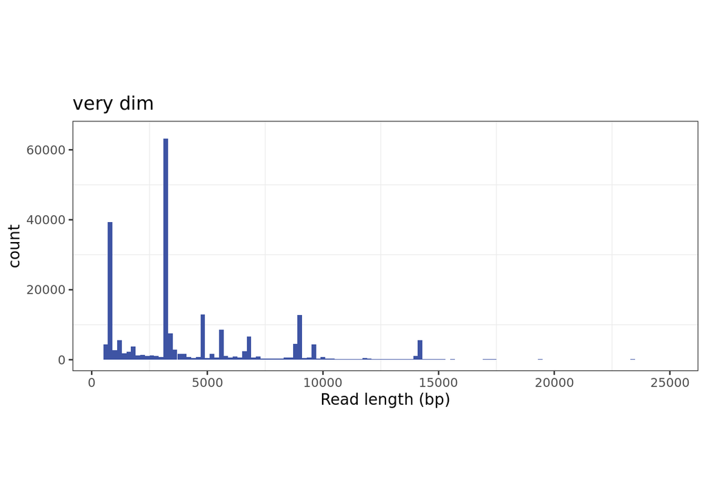

```r
library(dplyr)
library(ggplot2)
library(ggpubr)
library(tidyr)

setwd("/lustre/scratch126/gengen/projects/escramble")

# Load data

OTX2.read.length.df <- readRDS("/lustre/scratch126/gengen/projects/escramble/Notebook/002_OTX2_superenhancer_scramble/rds/OTX2.read.length.df.rds")

# Clean and save as a table

OTX2.read.summary.df <- OTX2.read.length.df %>% dplyr::select(read.id, gate = sample.id, replicate) %>% distinct()
write.table(OTX2.read.summary.df, "/lustre/scratch126/gengen/projects/escramble/Notebook/002_OTX2_superenhancer_scramble/rds/OTX2_loxP7_read_summary.tsv", sep = "\t", col.names = T, row.names = F, quote = F)

# Plot

OTX2.read.length.very.dim.plot <- OTX2.read.length.df %>% filter(read.length >= 400 & read.length <= 25000) %>%
  filter(sample.id == "very_dim") %>%
  ggplot(aes(x=read.length)) +
  geom_histogram(binwidth=200, fill="#3E54A4") + ggtitle("very dim") + xlab("Read length (bp)") + xlim(400, 25000) + ylim(0,65000) +
  theme_bw() + theme(aspect.ratio=0.4, panel.grid.major = element_blank())
OTX2.read.length.very.dim.plot
```

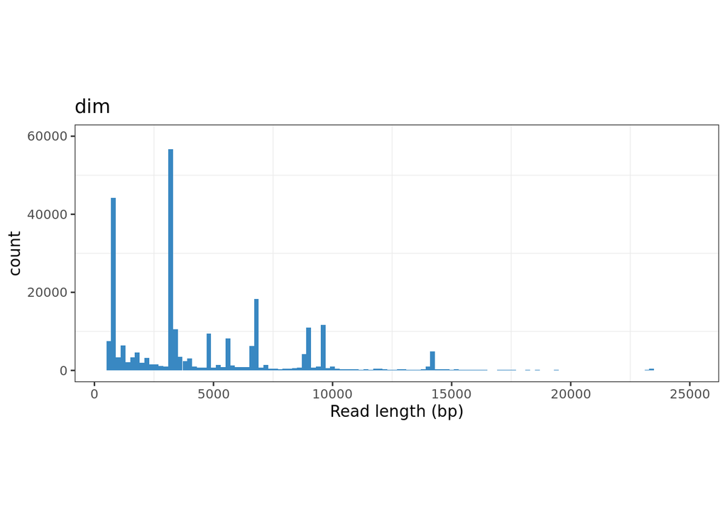

```r
OTX2.read.length.dim.plot <- OTX2.read.length.df %>% filter(read.length >= 400 & read.length <= 25000) %>%
  filter(sample.id == "dim") %>%
  ggplot(aes(x=read.length)) +
  geom_histogram(binwidth=200, fill="#3988C2") + ggtitle("dim") + xlab("Read length (bp)") + xlim(400, 25000) + ylim(0,60000) +
  theme_bw() + theme(aspect.ratio=0.4, panel.grid.major = element_blank())
OTX2.read.length.dim.plot
```